## Programming basics

We teach R because it greatly facilitates data analysis, the main topic of this book. Coding in R we can efficiently perform exploratory data analysis, build data analysis pipelines and prepare data visualization to communicate results. However R is not just a data analysis environment but a programming language. Advanced R programmers can develop complex packages and even improve R itself, but we do not cover advanced progamming in this book. However,in this section we introduce three key programming concepts: conditional expressions, for-loops and functions. These are not just key building blocks for advanced programming, but ocassionaly come in handy during data analysis. We also provide a list of power function that we dot not cover in the book but are worth knowing about as they are powerful tools commonly by expert data analysists.

### Conditionals expressions

Conditionals expressions are one of the basic features of programming. The most common conditional expression is the if-else statement. In R, we can actually perform quite a bit of data analysis without conditionals. However, they do come up occasionally and if once you start writing your own functions and packages you will definitely need them.

Here is a very simple example showing the general structure of an if-else statement. The basic idea is to print the reciprocal of `a` unless `a` is 0:

```r
a <- 0

if(a!=0){
  print(1/a)
} else{
  print("No reciprocal for 0.")
}
```

```
## [1] "No reciprocal for 0."
```

Let’s look at one more example using the US murders data frame.

Here is a very simple example that tells us which states, if any, have a murder rate lower than 0.5 per 100,000. The if statement protects us from the case in which no state satisfies the condition.

```r
ind <- which.min(murder_rate)

if(murder_rate[ind] < 0.5){
  print(murders$state[ind])
} else{
  print("No state has murder rate that low")
}
```

```
## [1] "Vermont"
```

If we try it again with a rate of 0.25 we get a different answer:

```r
if(murder_rate[ind] < 0.25){
  print(murders$state[ind])
} else{
  print("No state has a murder rate that low.")
}
```

```
## [1] "No state has a murder rate that low."
```

A related function that is very useful is `ifelse`. This function takes three arguments: a logical and two possible answers. If the logical is `TRUE` the first answer is returned and if `FALSE` the second. Here is an example

```r
a <- 0
ifelse(a > 0, 1/a, NA)
```

```
## [1] NA
```

The function is particularly useful because it works on vectors. It examines each element of the logical vector and returns corresponding answers from the accordingly.

```r
a <- c(0,1,2,-4,5)
result <- ifelse(a > 0, 1/a, NA)
```

This table helps us see what happned:

| a | is_a_positive | answer1 | answer2 | result |
| --- | --- | --- | --- | --- |
| 0 | FALSE | Inf | NA | NA |
| 1 | TRUE | 1.00 | NA | 1.0 |
| 2 | TRUE | 0.50 | NA | 0.5 |
| -4 | FALSE | -0.25 | NA | NA |
| 5 | TRUE | 0.20 | NA | 0.2 |

Here is an example of how this function can be readily used to replace all the missing values in a vector with zeros:

```r
data(na_example)
no_nas <- ifelse(is.na(na_example), 0, na_example)
sum(is.na(no_nas))
```

```
## [1] 0
```

Two other useful function are `any` and `all`. The `any` function takes a vector of logical and returns `TRUE` if any of the entries is `TRUE`.The `all` function takes a vector of logical and returns `TRUE` if all of the entries is `TRUE`. Here is an example.

```r
z <- c(TRUE, TRUE, FALSE)
any(z)
```

```
## [1] TRUE
```

```r
all(z)
```

```
## [1] FALSE
```

### Defining Functions

As you become more experienced you will find yourself needeing to perform the same operations over and over. A simple example is computing average. We can compute the average of a vector `x` using the `sum` and `length` functions: `sum(x)/length(x)`. But because we do this so often it is much more efficient to write a function that performs this operation and thus someone already wrote the `mean` function. However, you will encounter situations in which the function does not already exist so R permits you to write your own. A simple version of function that computes the average can be defined like this

```r
avg <- function(x){
  s <- sum(x)
  n <- length(x)
  s/n
}
```

Now `avg` is a function that computes the mean:

```r
x <- 1:100
identical(mean(x), avg(x))
```

```
## [1] TRUE
```

Note that variables defined inside a function are not saved in the workspace. So while we use `s` and `n` when we call `avg`, there values are created and changed only during the call. Here are illustrative example:

```r
s <- 3
avg(1:10)
```

```
## [1] 5.5
```

```r
s
```

```
## [1] 3
```

Note how `s` is still 3 after we call `avg`.

Also not that The functions you define can have multiple arguments as well as default values. For example we can define a function that computes either the arithmetic or geometric average depending on a user defined variable like this

```r
avg <- function(x, arithmetic = TRUE){
  n <- length(x)
  ifelse(arithmetic, sum(x)/n, prod(x)^(1/n))
}
```

We will learn more about how to create functions through experience as we face more complex tasks.

### For loops

The formula for the sum $1+2+\dots+n$ is $n(n+1)/2$. What if we weren’t sure that was the right function, how could we check? Using what we learned about functions we can create on that computes the $S_n$:

```r
compute_s_n <- function(n){
  x <- 1:n
  sum(x)
}
```

Perhaphs the simplest example of a for loop is this useless piece of code:

```r
for(i in 1:5){
  print(i)
}
```

```
## [1] 1
## [1] 2
## [1] 3
## [1] 4
## [1] 5
```

And here is the for loop we would write for our $S_n$ example:

```r
m <- 25
s_n <- vector(length = m) # create an empty vector
for(n in 1:m){
  s_n[n] <- compute_s_n(n)
}
```

In each iteration $n=1$, $n=2$, etc…, we compute $S_n$ and store it in the $n$th entry of `s_n`.

Now we can create a plot to get search for a pattern

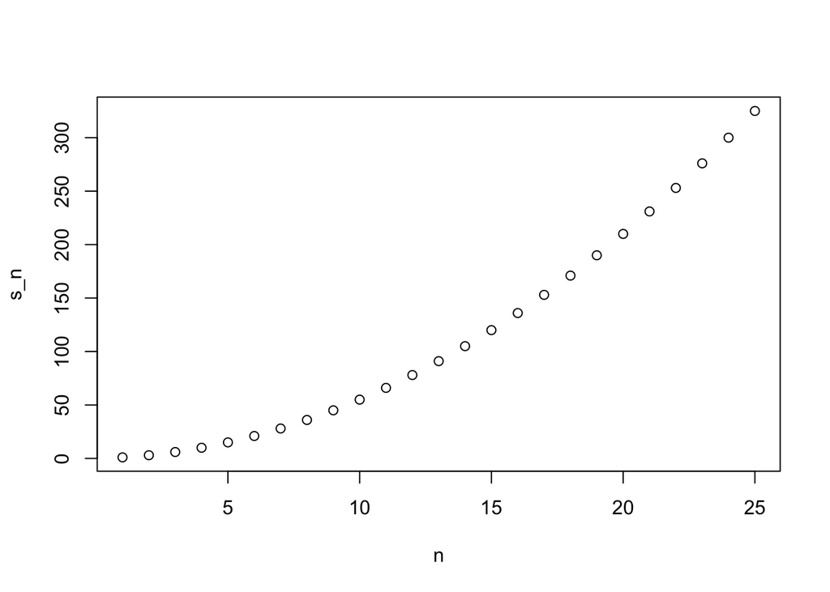

```r
n <- 1:m
plot(n, s_n)
```

If you noticed that it appears to be a quadratic, you are on the right track because the formula is $n(n+1)/2$ which we can confirm with a table

```
##   s_n formula
## 1   1       1
## 2   3       3
## 3   6       6
## 4  10      10
## 5  15      15
## 6  21      21
```

We can also overlay the two results by using the function `lines` to draw a line over the previously plotted points:

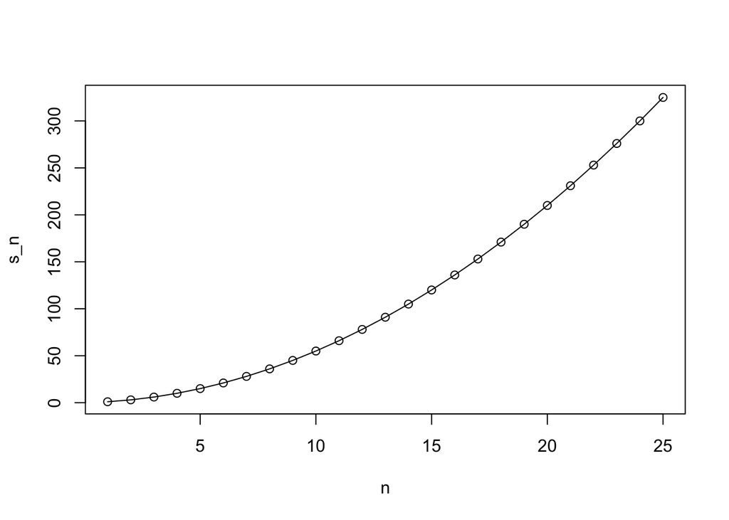

```r
plot(n, s_n)
lines(n, n*(n+1)/2)
```

### Other functions

It turns out that we rarely use for loops in R. This is because there are usually more powerful ways to perform the same task. Functions that are typically used instead of for loops are the apply family: `apply`, `sapply`, `tapply`, and `mapply`. We do not cover these functions in this book but they are worth learning if you intend to go beyond this introduction. Other functions that are widely used are `split`, `cut`, and `Reduce`.

### Assessment

1. What will this conditional expression return?

   ```r
   x <- c(1,2,-3,4)

   if(all(x>0)){
     print("A ll Postives")
   } else{
     print("Not all positives")
   }
   ```

   ```
   ## [1] "Not all positives"
   ```

2. Which of the following expressions is always `FALSE` when at least one entry of a logical vector `x` is TRUE?

   A. `all(x)` B. `any(x)` C. `any(!x)` D. `all(!x)`
3. The function `nchar` tells you how many characters long a character vector is. For examples

   ```r
   library(dslabs)
   data(murders)
   char_len <- nchar(murders$state)
   char_len[1:5]
   ```

   ```
   ## [1]  7  6  7  8 10
   ```

   Write a line of code that assigns to the object `new_names` the state abbreviation when the state name is longer than 8 characters.
4. Create a function `sum_n`that for any given value, say $n$, computes the sum of the integers from 1 to n (inclusive). Use the function to determine the some of integers from 1 to 5,000.
5. Create a function `altman_plot` that takes two arguments `x` and `y` and plots the difference against the sum
6. After running the code below, what is the value of `x`?

   ```r
   x <- 3
   my_func <- function(y){
   x <- 5
   y+5
   }
   ```

7. Write a function `compute_s_n` that for any given $n$ computes the sum $S_n = 1^2 + 2^2 + 3^2 + \dots n^2$. Report the value of the sum when $n=10$.
8. Now define an empty numerical vector `s_n` of size 25 using `s_n <- vector("numeric", 25)` and store in the results of $S_1, S_2, \dots S_25$.
9. Plot $S_n$ versus $n$. Use points defined by $n=1,\dots,25$.
10. Confirm that the formula for this sum is $S_n= n(n+1)(2n+1)/6$: